# Weekly Energy Charts

June 24, 2022

[Sign up here to get on our email list](https://docs.google.com/forms/d/e/1FAIpQLSckqeGjUvIlhveVyjmkXe913tzQRLANqPNQzEZTUQD2hQxH8g/viewform?usp=pp_url)

# Featured Stories

## Hypocrisy in F1?

#### Erica Beattie

F1 driver Sebastian Vettel arrived at the Montreal Grand Prix in an anti-oilsands t-shirt and proceeded to [criticize Alberta oilsands operations](https://www.cbc.ca/amp/1.6493309) in an interview. His helmet also displayed a similar message.

Vettel has used his platform on other occasions to address climate change and other environmental issues.

Predictably, he received scathing criticism from Alberta’s Energy Minister Sonya Savage. The hypocrisy of his position made him an easy target: his career relies on fuel and one of his sponsors is Saudi-Arabia’s state-owned oil giant Aramco.

The Alberta energy industry has been trying to change people’s perception of it for years now, and is even taking steps towards achieving net zero. But it seems that not everyone is convinced that much, if anything, has changed. Unfortunately, neither incidents like these nor the predictable Alberta response do much to improve that perception.

## Power Demand Soars in Texas

#### [Yousaff Habib](https://www.linkedin.com/in/yousaff-habib-6684891a5/)

Heat waves have become more intense, common, and last longer in major cities across the United States. As a result, AC usage has risen in conjunction, and this has posed an issue for power grids across these cities. In Texas, a single megawatt can power 1000 homes under regular conditions, but in a heatwave, the number drops to a mere 200. As such, with temperatures reaching highs of 38°C, the demand for power has skyrocketed recently in Texas, shattering previous records for power use with a peak demand of [74,917 MW](https://www.ercot.com/gridinfo/load/load_hist). In spite of this, The Electric Reliability Council of Texas (ERCOT) maintains they have the resources to meet any foreseeable demand.

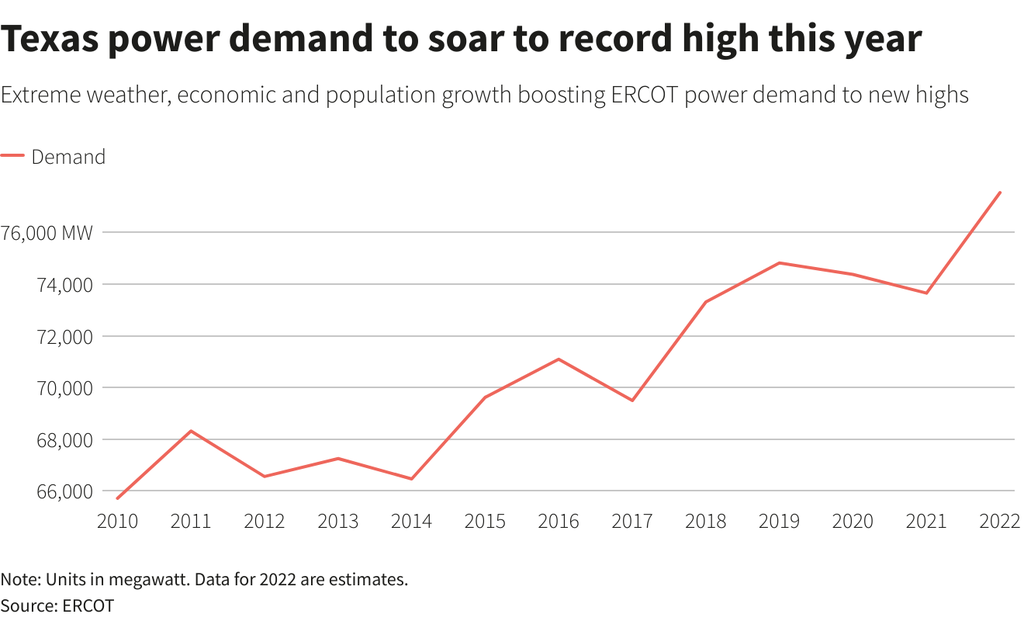

Texas Yearly Peak Power Demand, Credit: Reuters

Simalarly, [provinces in China](https://news.rthk.hk/rthk/en/component/k2/1654223-20220622.htm) have been reporting similar upticks in power use due to heatwaves, and with summer just beginning, we will likely see this demand grow further there too. And, with China’s reliance on coal power, more power demand means more emissions which, in turn, creates more climate-changing emissions.

More information and statistics can be found on the [ERCOT website.](https://www.ercot.com/about)

## Methane omissions?

#### Andrew Leach

A story this week at [The Narwhal](https://thenarwhal.ca/) from Carl Meyer really raised my eyebrows and highlights how important details can be in policy design.

Meyer’s scoop alleges that CNRL was able to persuade the government of Rachel Notley and the Alberta Energy Regulator to change the way methane emissions regulations were enforced.

[Read it here](https://thenarwhal.ca/alberta-climate-methane-cnrl/)

Methane is a potent greenhouse gas, and reducing methane has long been touted by Alberta’s oil and gas industry as a low cost (even negative cost) way to reduce emissions. Meyer’s story is very detailed, so I’ll leave it to you to [read here](https://thenarwhal.ca/alberta-climate-methane-cnrl/).

# Oil

## Weekly Crude Prices

### Feature Crude

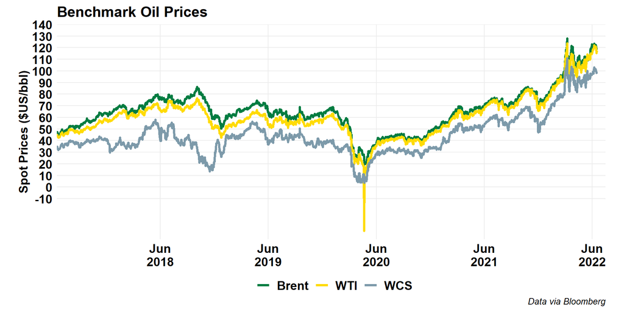

### Alberta Crude

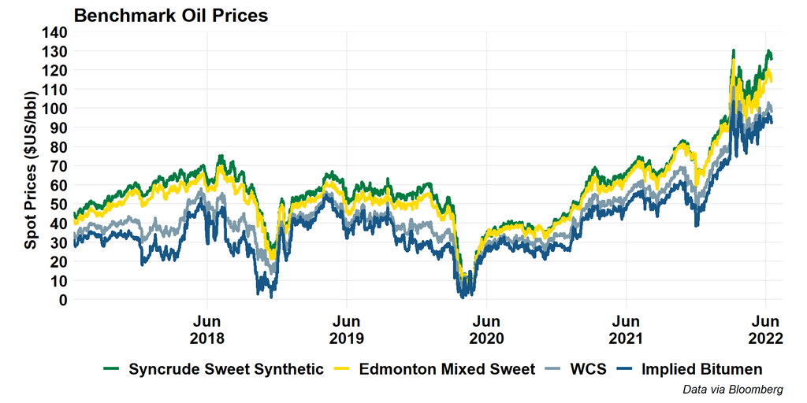

### Alberta Crude (Short)

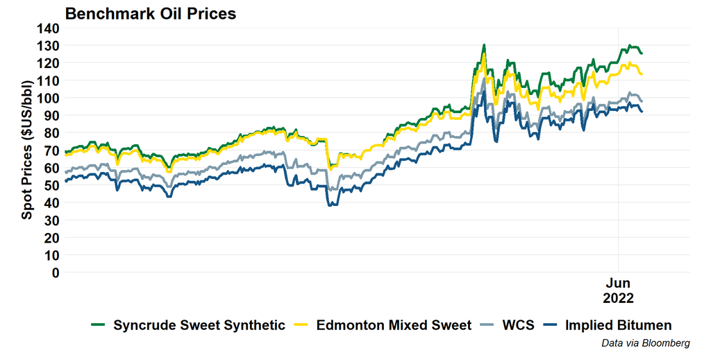

### US Crude

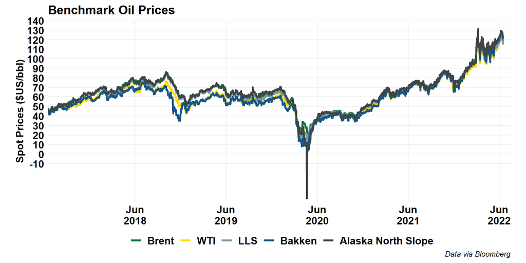

### Global Crude

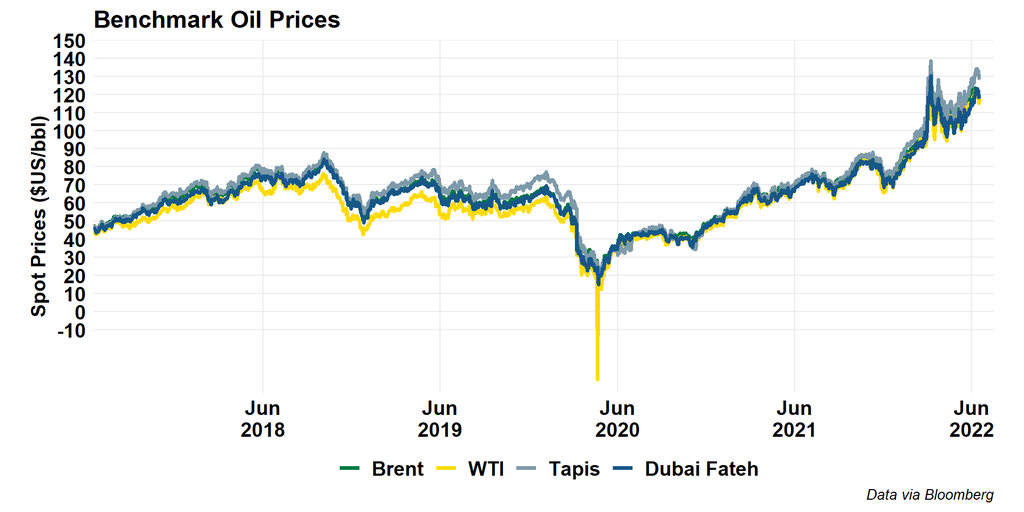

## Oil Price Differentials

### Brent-WTI

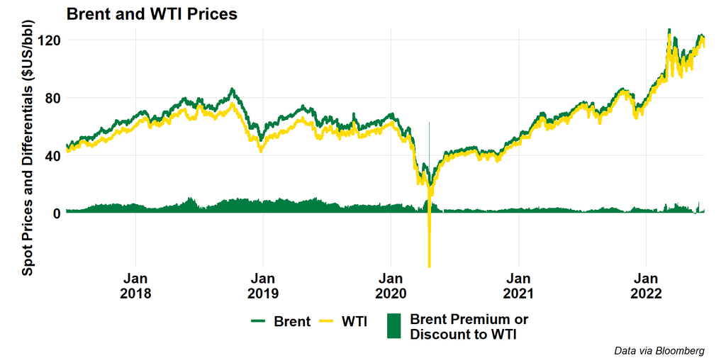

### WTI-WCS

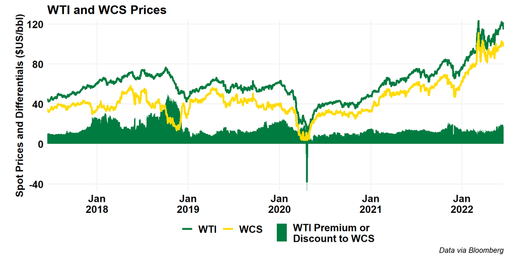

### WTI-WCS (Short)

[figure not shown]

### Maya-WCS

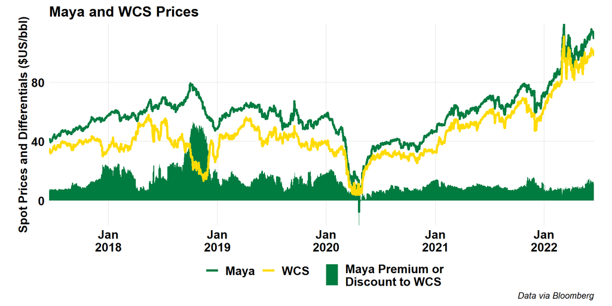

### WTI Cushing vs MEH

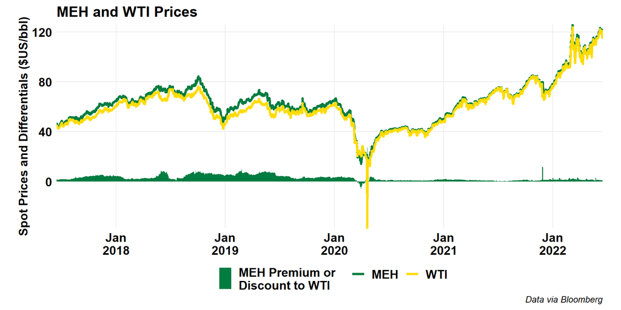

## Forward Curves

### WTI

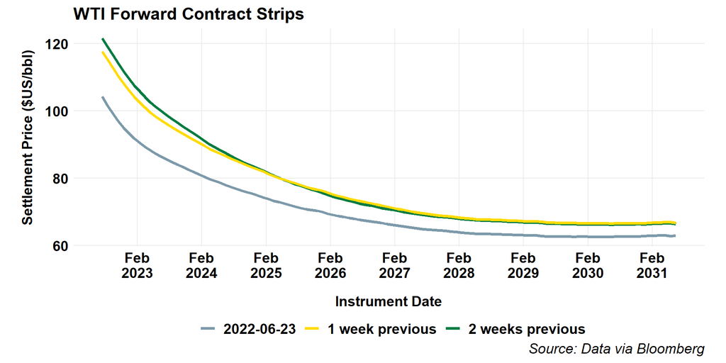

### Brent

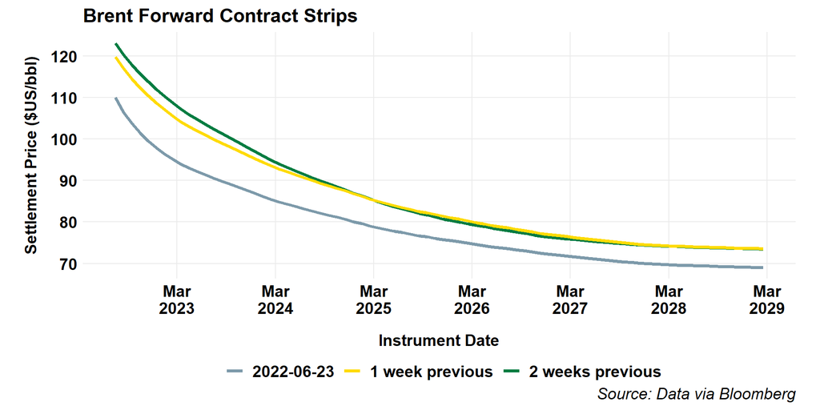

## Canadian Crude Supply and Disposition

### Production

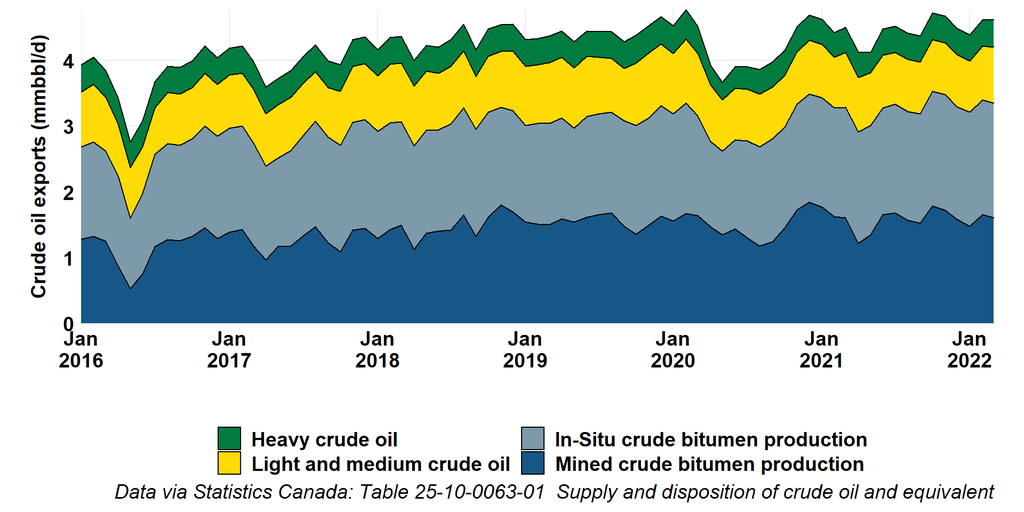

### Imports

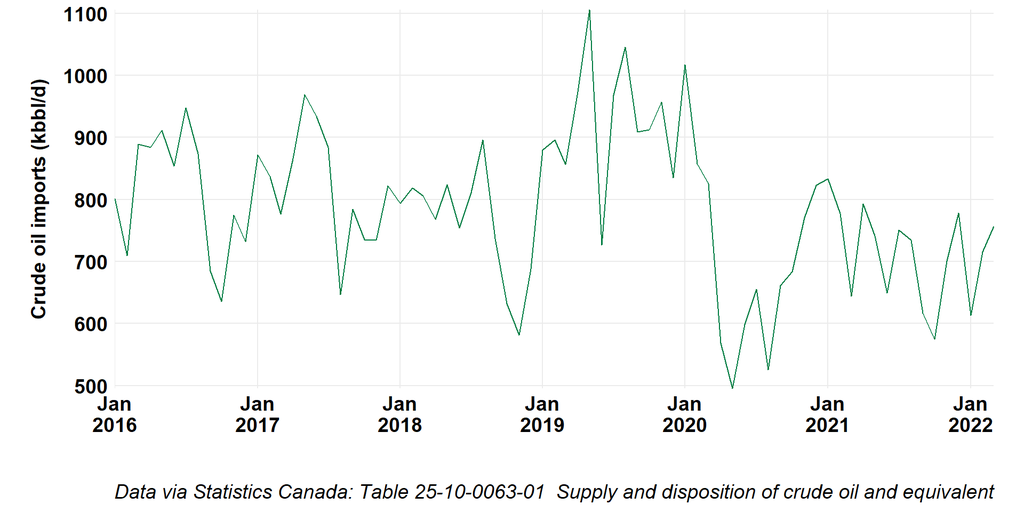

### Exports

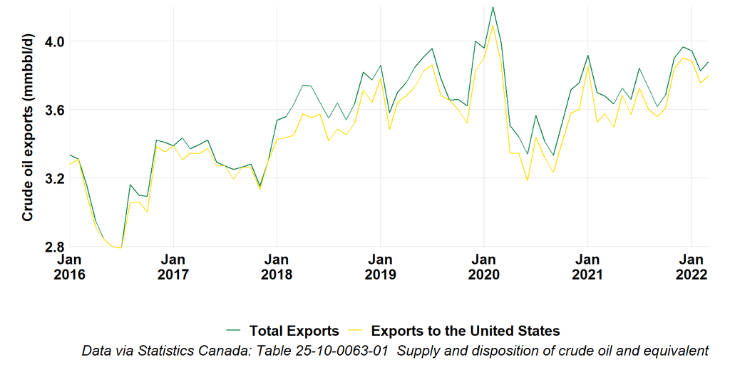

### Rail Exports

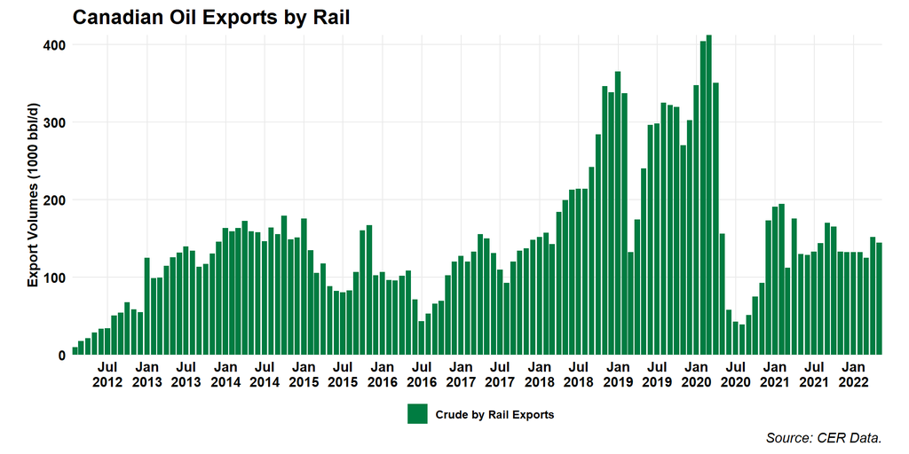

## US Oil

### Production

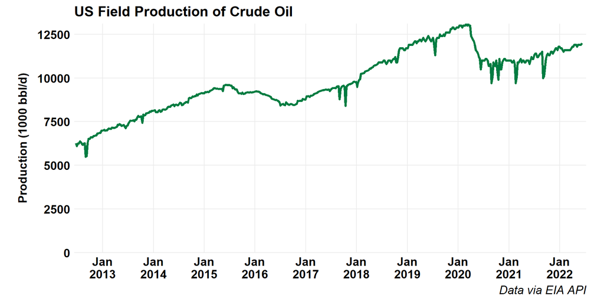

### LTO Production by Play

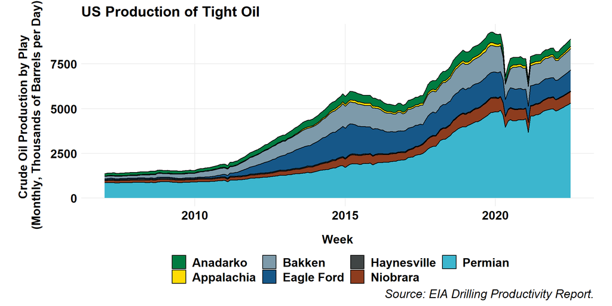

### Net Imports

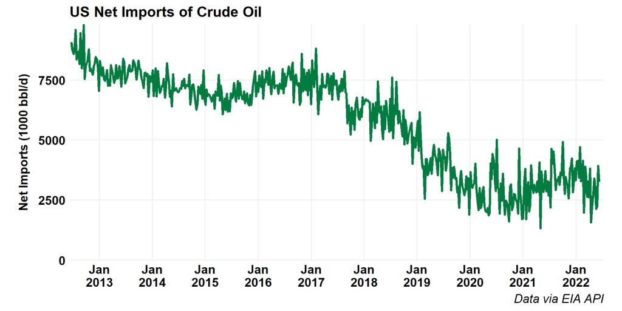

### Oil and Product Net Imports

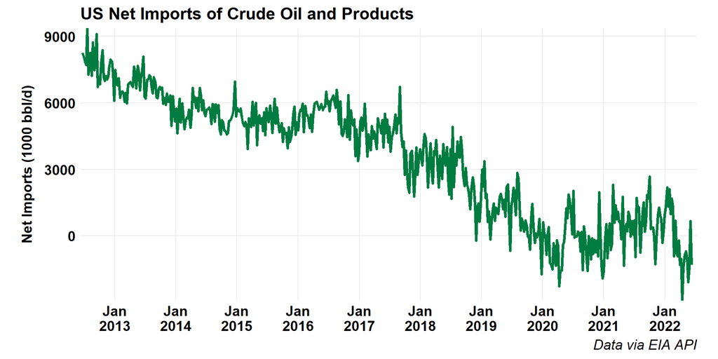

### Inventories

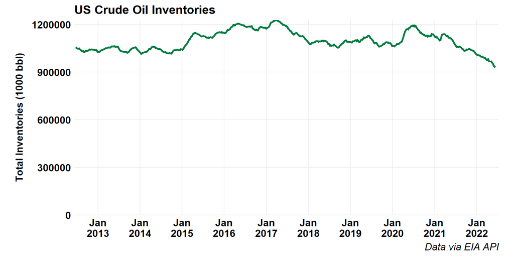

# Refined Products

## Canadian Gasoline Prices

### Map

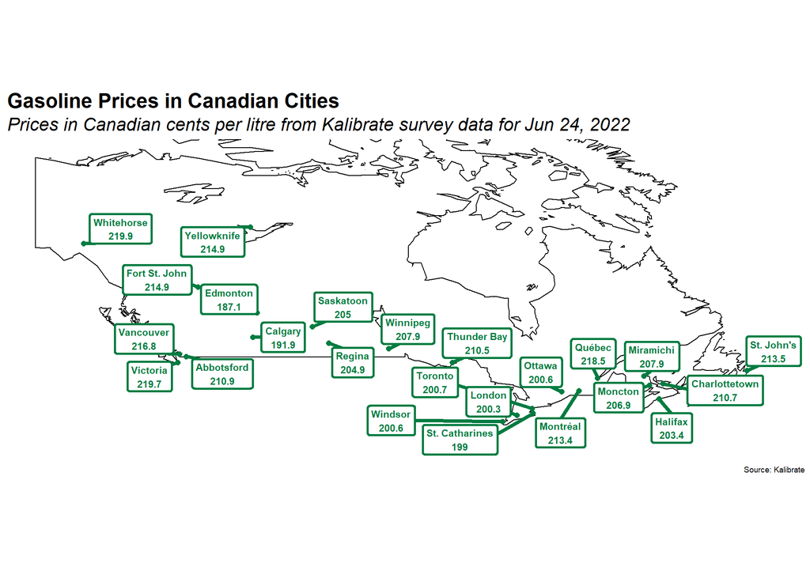

### Historic Gasoline Prices

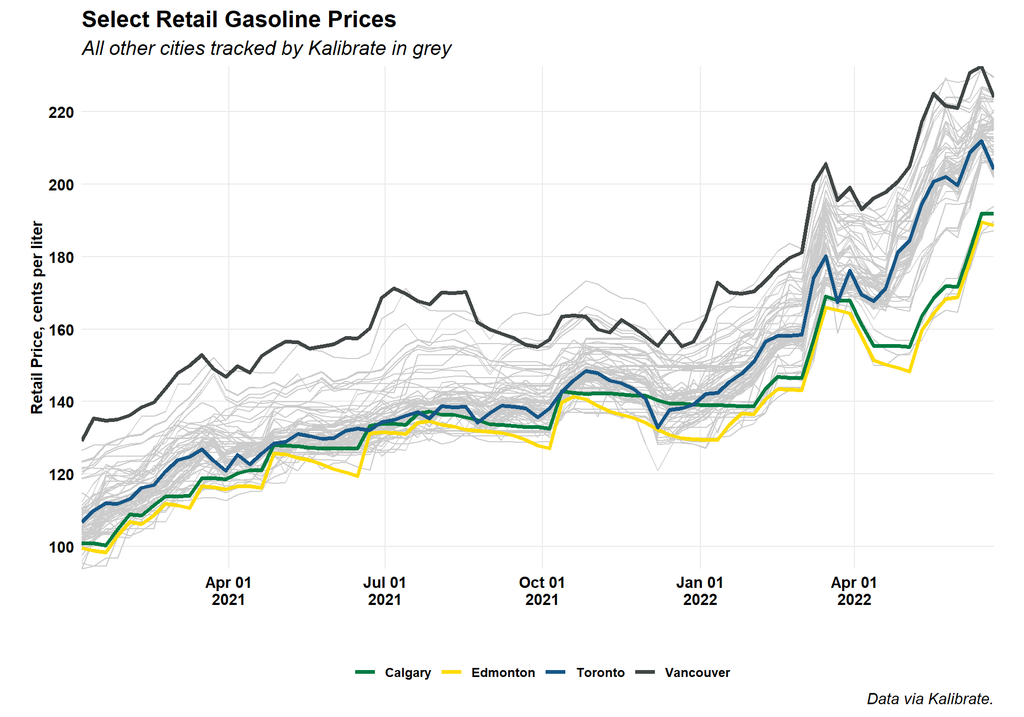

### Historic Gasoline Prices in BTC

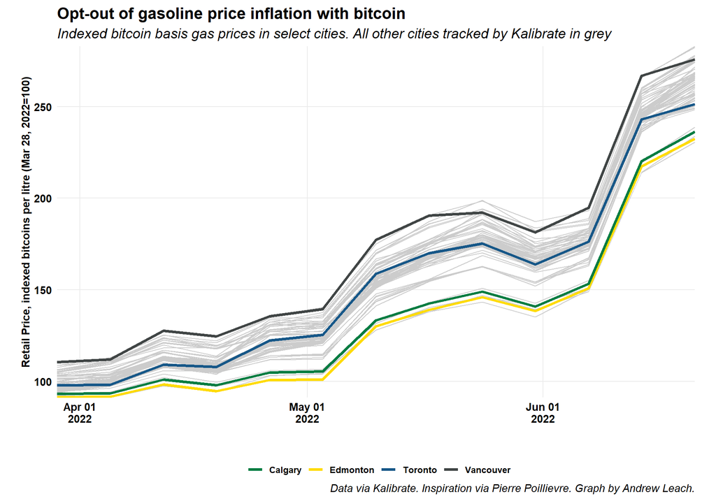

### Historic Diesel Prices

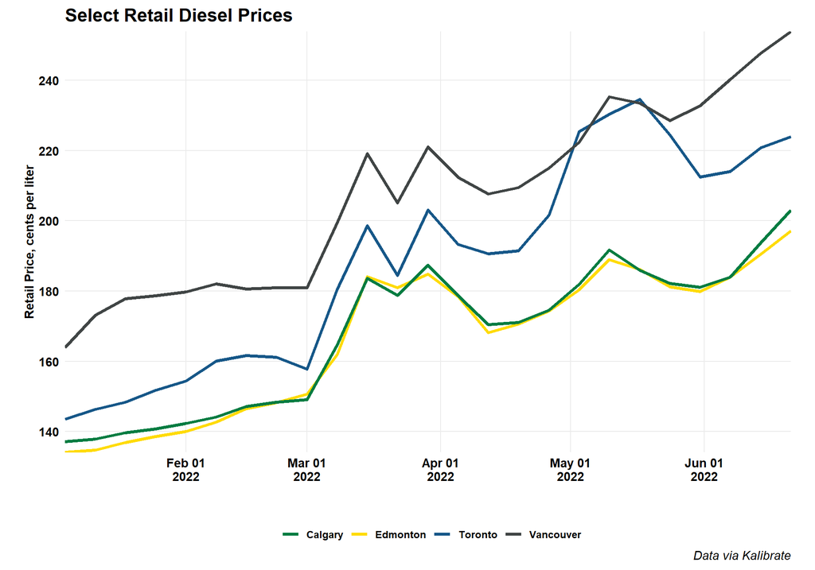

## Canadian Refinery Runs

### Canadian Refinery Runs

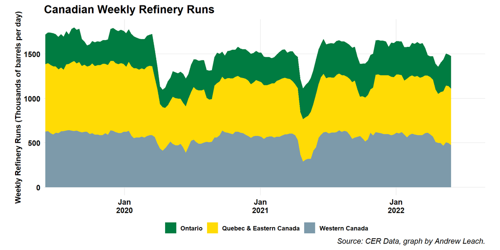

### Western Canada Refinery Runs

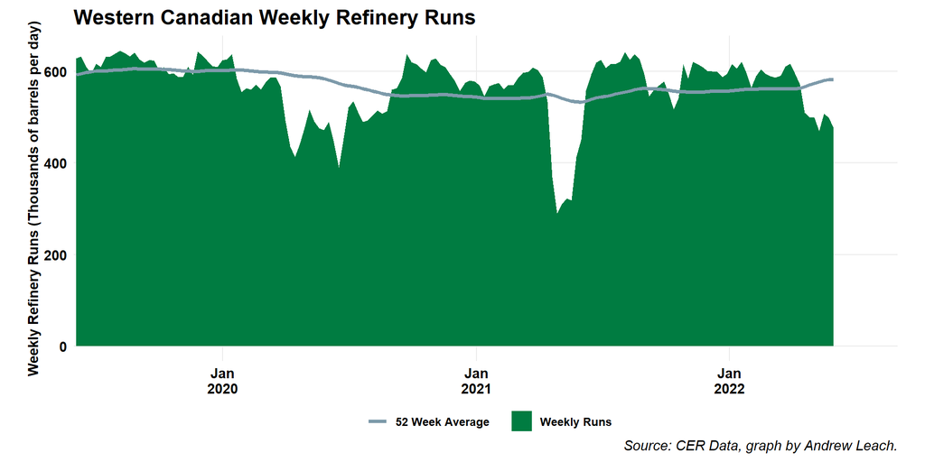

# Natural Gas

## Natural Gas Market Summary

### Feature Gas

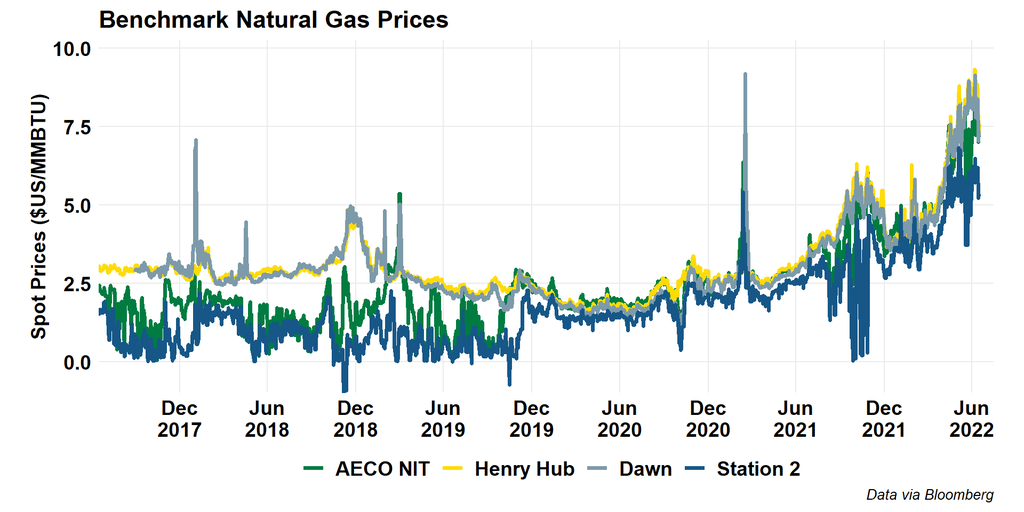

### Feature Gas (Short)

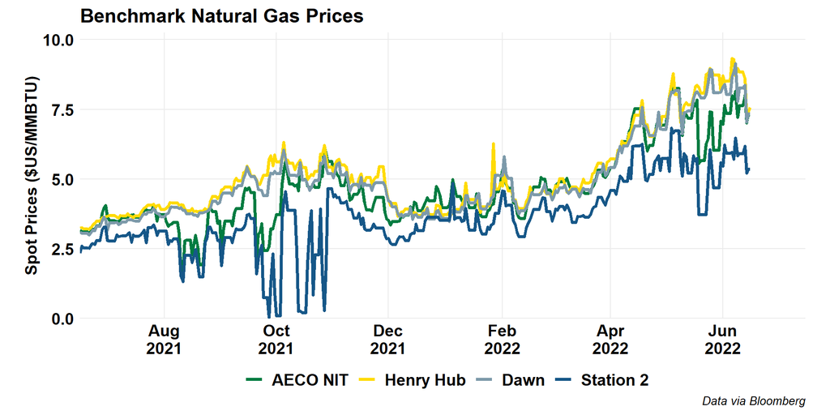

### Global Gas

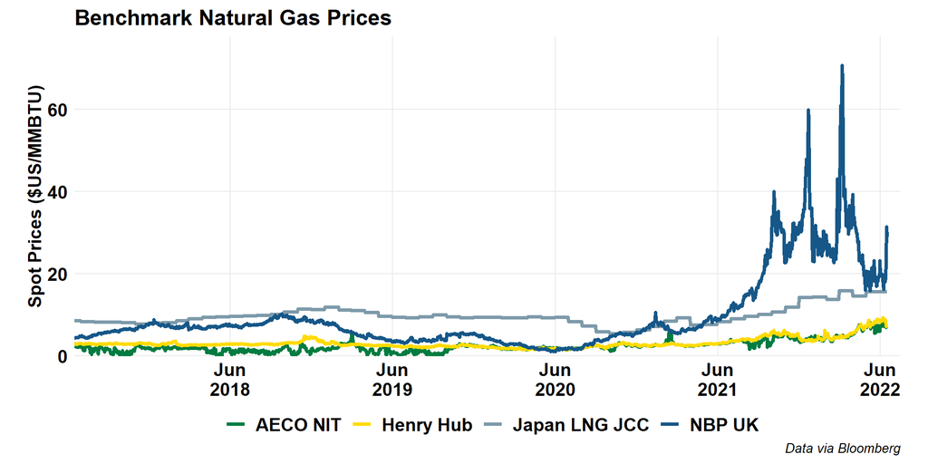